# Lab 3

- Show All Code
- Hide All Code
- View Source

Author

Jia Jiang

```r
library(tidyverse)
library(here)

surveys <- read_csv(here("hiphop.csv"))

hiphop_clean <- surveys |> mutate(fam = as.factor(familiarity))
hiphop_clean |> distinct(word)
```

```
# A tibble: 64 × 1
   word
   <chr>
 1 [to be] ghost
 2 5-0
 3 A-town
 4 ashy
 5 ay yo trip
 6 ballin'
 7 beezy
 8 bones
 9 boo
10 boughie
# … with 54 more rows
```

```r
hiphop_clean |> mutate(new_ethnic = case_when(ethnic == "white" ~ "white", TRUE ~ "non-white"))
```

```
# A tibble: 10,752 × 40
   word   subj  sex     age ethnic   city county  intl vocal class…¹  folk  rock
   <chr>  <chr> <chr> <dbl> <chr>   <dbl>  <dbl> <dbl> <dbl>   <dbl> <dbl> <dbl>
 1 [to b… p15   Fema…    20 white   33283 1.16e6     0     0       0     0     1
 2 [to b… p53   Fema…    17 white   34033 3.96e5     0     0       0     0     0
 3 [to b… p136  Male     41 white    8789 5.87e4     0     2       0     0     0
 4 [to b… p36   Fema…    18 white     712 1.49e5     0     0       0     1     1
 5 [to b… p118  Fema…    18 white   24280 1.54e5     0     3       3     0     1
 6 [to b… p106  Male     19 white  281262 5.06e5     0     0       0     0     0
 7 [to b… p70   Fema…    18 white  385542 1.16e6     0     0       0     2     0
 8 [to b… p107  Male     18 white     326 5.06e5     0     0       0     0     1
 9 [to b… p102  Male     19 asian    8471 1.01e5     0     0       0     0     0
10 [to b… p83   Male     19 white   72878 1.16e6     0     1       0     0     4
# … with 10,742 more rows, 28 more variables: country <dbl>, pop <dbl>,
#   alternative <dbl>, hiphop <dbl>, unclassifiable <dbl>, countyBlack <dbl>,
#   jayz <dbl>, barkley <dbl>, boondocks <dbl>, monique <dbl>, bieber <dbl>,
#   asianMove <dbl>, blackMove <dbl>, hispanicMove <dbl>, nativeMove <dbl>,
#   SAAMEMove <dbl>, whiteMove <dbl>, blackWeekly <dbl>, jayz1 <dbl>,
#   boondocks1 <dbl>, familiarity <dbl>, trial <dbl>, fam1 <dbl>,
#   popularityScore <dbl>, numPreferredArtists <dbl>, …
```

```r
hiphop_new <- hiphop_clean |> select(c(sex, age, ethnic, subj)) |> distinct(subj, .keep_all = TRUE)
```

2.The data surveys individual musical tastes and correlating that with the familiarity of AAE words. They also include characteristics of the individuals. The contect of the study is to test if preference in music tastes can predict AAE knowlegde. The Variables were recorded through 168 undergrads in University of Minnesota. The sample was selected by who was not african american.

3.The rows are the word, the person, music genre, and the familiarity. Row is a person’s response to the familiarity of the word and other factors that may contribute to that familiarity.

4. It is replaced with NA, unknown, and missing values was replaced by mean values. The benefit is that it actually correlate with missing value instead of just having zero there but the drawback is that you can not do some functions with it. Another benefit would be that it allows us to do math on the row although it was missing values in plot for blackWeekly. But unknown is bad for a data graph that is separated by racial groups because putting them into one group make the graph not cohesive.

6.There is 64 distinct words

8. because there are more racial groups than white and non-white and grouping all non-whites into a category is racist.

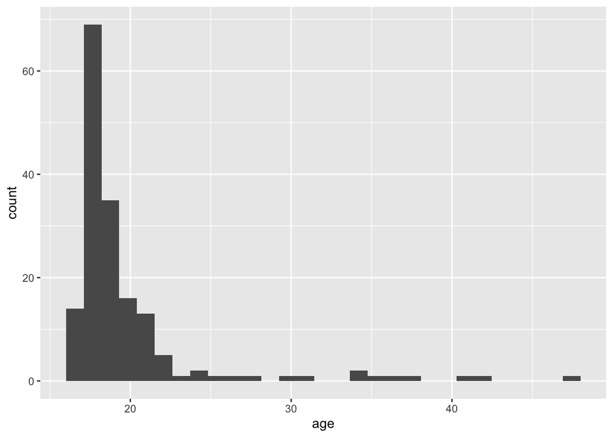

   ```r
   ggplot(data =hiphop_new, aes(x=age)) +
     geom_histogram()
   ```

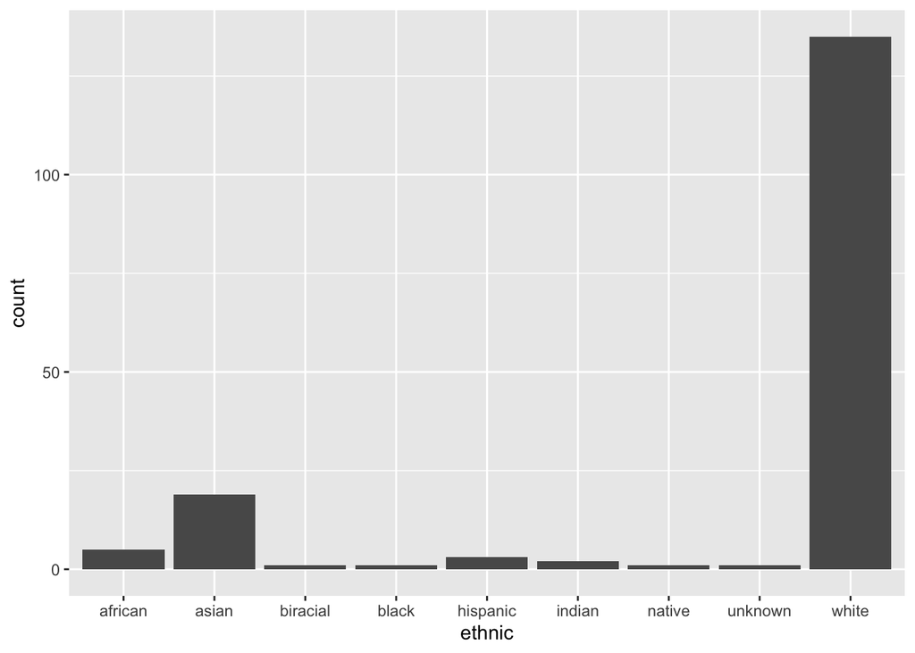

   ```r
   ggplot(data =hiphop_new, aes(x=ethnic)) +
     geom_bar()
   ```

11.min: catch the vapors max: off the hook

```r
hiphop_clean |> group_by(word) |> filter(age<20) |> summarise(avg = mean(familiarity)) |> slice_max(avg)
```

```
# A tibble: 1 × 2
  word           avg
  <chr>        <dbl>
1 off the hook  4.42
```

```r
hiphop_clean |> group_by(word) |> filter(age<20) |> summarise(avg = mean(familiarity)) |> slice_min(avg)
```

```
# A tibble: 1 × 2
  word               avg
  <chr>            <dbl>
1 catch the vapors  1.03
```

12.max : feel me min: break someone out, dukey rope, plex, rollie

```r
hiphop_clean |> group_by(word) |> filter(ethnic != "white", sex == "Female") |> summarise(avg = mean(familiarity)) |> slice_max(avg)
```

```
# A tibble: 1 × 2
  word      avg
  <chr>   <dbl>
1 feel me  4.19
```

```r
hiphop_clean |> group_by(word) |> filter(ethnic != "white", sex == "Female") |> summarise(avg = mean(familiarity)) |> slice_min(avg)
```

```
# A tibble: 4 × 2
  word                avg
  <chr>             <dbl>
1 break someone out     1
2 dukey rope            1
3 plex                  1
4 rollie                1
```

```r
hiphop_clean |> group_by(word) |> filter(ethnic == "white", age>30, sex=="male") |> summarise(avg = mean(familiarity)) |> slice_max(avg)
```

```
# A tibble: 0 × 2
# … with 2 variables: word <chr>, avg <dbl>
```

```r
hiphop_clean |> group_by(word) |> filter(ethnic == "white", age>30, sex=="male") |> summarise(avg = mean(familiarity)) |> slice_min(avg)
```

```
# A tibble: 0 × 2
# … with 2 variables: word <chr>, avg <dbl>
```

14.Subject 17 because they match all the filters and knows the most in the beiber option

```r
hiphop_clean  |> distinct(subj, .keep_all = TRUE) |> filter(ethnic == "white" & sex == "Male", city < 60000, city > 10000, age > 17, age < 23 ) |> slice_max(bieber)
```

```
# A tibble: 1 × 39
  word     subj  sex     age ethnic  city county  intl vocal class…¹  folk  rock
  <chr>    <chr> <chr> <dbl> <chr>  <dbl>  <dbl> <dbl> <dbl>   <dbl> <dbl> <dbl>
1 [to be]… p17   Male     18 white  56377 331582     0     1       0     0     1
# … with 27 more variables: country <dbl>, pop <dbl>, alternative <dbl>,
#   hiphop <dbl>, unclassifiable <dbl>, countyBlack <dbl>, jayz <dbl>,
#   barkley <dbl>, boondocks <dbl>, monique <dbl>, bieber <dbl>,
#   asianMove <dbl>, blackMove <dbl>, hispanicMove <dbl>, nativeMove <dbl>,
#   SAAMEMove <dbl>, whiteMove <dbl>, blackWeekly <dbl>, jayz1 <dbl>,
#   boondocks1 <dbl>, familiarity <dbl>, trial <dbl>, fam1 <dbl>,
#   popularityScore <dbl>, numPreferredArtists <dbl>, …
```